# Data_Analysis_Leaps_Subset_Selection.Rmd

Methodology from: https://rstudio-pubs-static.s3.amazonaws.com/2897_9220b21cfc0c43a396ff9abf122bb351.html Applied to the California Housing Data Set

```r
# Used Google Colab to get quicker turn around on this, so had to install these packages
# Using Google Colab for R is rad: https://stackoverflow.com/questions/54595285/how-to-use-r-with-google-colaboratory
if(!require(leaps)) install.packages("leaps", repos = "http://cran.us.r-project.org")
if(!require(caret)) install.packages("caret", repos = "http://cran.us.r-project.org")
if(!require(car)) install.packages("car", repos = "http://cran.us.r-project.org")
library(readr)
library(knitr)
library(caret)
library(leaps)
library(car)

housing_data = read_csv("housing.csv")
is.factor(housing_data$ocean_proximity)
```

```
## [1] FALSE
```

```r
housing_data$ocean_proximity = as.factor(housing_data$ocean_proximity)
is.factor(housing_data$ocean_proximity)
```

```
## [1] TRUE
```

```r
regsubsets.out = regsubsets(median_house_value ~ ., data = housing_data,
               nbest = 1,       # 1 best model for each number of predictors
               nvmax = NULL,    # NULL for no limit on number of variables
               force.in = NULL, force.out = NULL, method = "exhaustive")
regsubsets.out
```

```
## Subset selection object
## Call: regsubsets.formula(median_house_value ~ ., data = housing_data,
##     nbest = 1, nvmax = NULL, force.in = NULL, force.out = NULL,
##     method = "exhaustive")
## 12 Variables  (and intercept)
##                           Forced in Forced out
## longitude                     FALSE      FALSE
## latitude                      FALSE      FALSE
## housing_median_age            FALSE      FALSE
## total_rooms                   FALSE      FALSE
## total_bedrooms                FALSE      FALSE
## population                    FALSE      FALSE
## households                    FALSE      FALSE
## median_income                 FALSE      FALSE
## ocean_proximityINLAND         FALSE      FALSE
## ocean_proximityISLAND         FALSE      FALSE
## ocean_proximityNEAR BAY       FALSE      FALSE
## ocean_proximityNEAR OCEAN     FALSE      FALSE
## 1 subsets of each size up to 12
## Selection Algorithm: exhaustive
```

```r
summary.out <- summary(regsubsets.out)
as.data.frame(summary.out$outmat)
```

```
##           longitude latitude housing_median_age total_rooms total_bedrooms
## 1  ( 1 )
## 2  ( 1 )
## 3  ( 1 )                                      *
## 4  ( 1 )
## 5  ( 1 )                                      *
## 6  ( 1 )          *        *                  *                          *
## 7  ( 1 )          *        *                  *                          *
## 8  ( 1 )          *        *                  *           *              *
## 9  ( 1 )          *        *                  *           *              *
## 10  ( 1 )         *        *                  *           *              *
## 11  ( 1 )         *        *                  *           *              *
## 12  ( 1 )         *        *                  *           *              *
##           population households median_income ocean_proximityINLAND
## 1  ( 1 )                                    *
```

[output cut: 37 more lines]

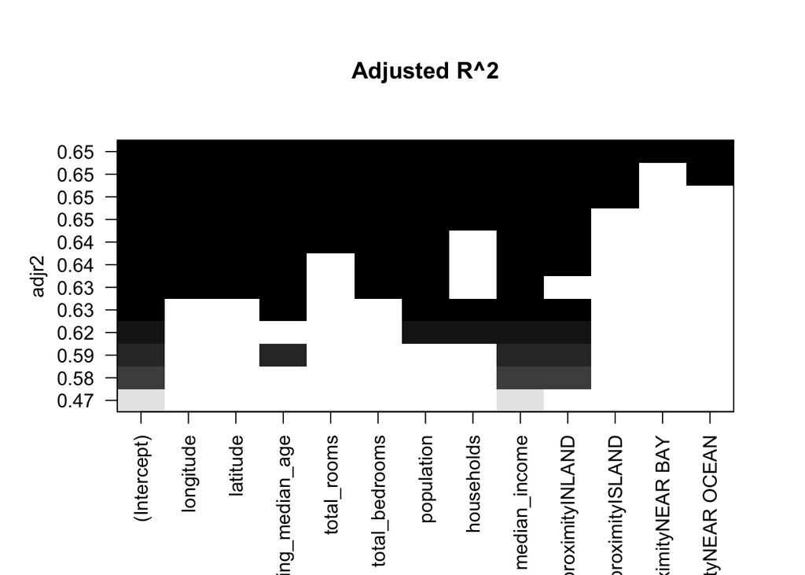

```r
## Adjusted R2
plot(regsubsets.out, scale = "adjr2", main = "Adjusted R^2")
```

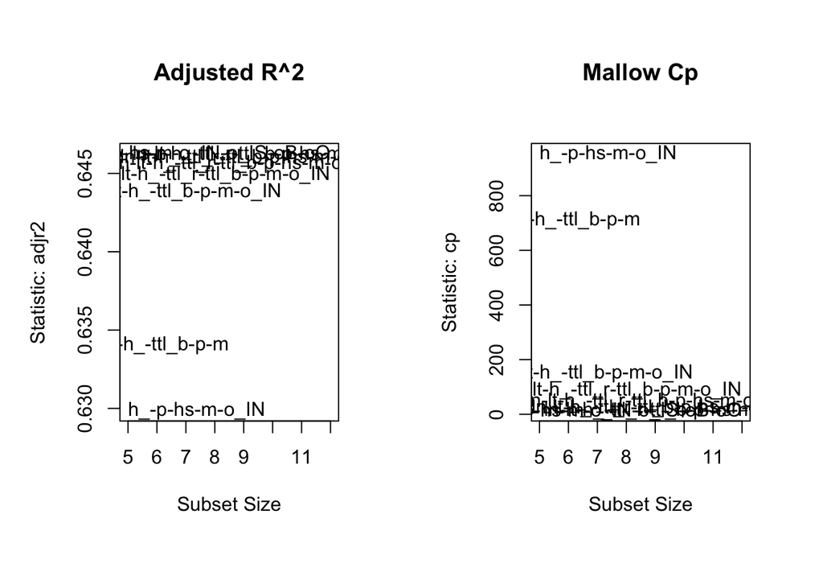

```r
library(car)
layout(matrix(1:2, ncol = 2))
## Adjusted R2
res.legend = subsets(regsubsets.out, statistic="adjr2", legend = FALSE, min.size = 5, main = "Adjusted R^2")
## Mallow Cp
res.legend = subsets(regsubsets.out, statistic="cp", legend = FALSE, min.size = 5, main = "Mallow Cp")
abline(a = 1, b = 1, lty = 2)
```

```r
res.legend
```

```
##                           Abbreviation
## longitude                           ln
## latitude                            lt
## housing_median_age                  h_
## total_rooms                      ttl_r
## total_bedrooms                   ttl_b
## population                           p
## households                          hs
## median_income                        m
## ocean_proximityINLAND             o_IN
## ocean_proximityISLAND             o_IS
## ocean_proximityNEAR BAY             oB
## ocean_proximityNEAR OCEAN           oO
```

```r
which.max(summary.out$adjr2)
```

```
## [1] 12
```

```r
summary.out$which[which.max(summary.out$adjr2),]
```

```
##               (Intercept)                 longitude
##                      TRUE                      TRUE
##                  latitude        housing_median_age
##                      TRUE                      TRUE
##               total_rooms            total_bedrooms
##                      TRUE                      TRUE
##                population                households
##                      TRUE                      TRUE
##             median_income     ocean_proximityINLAND
##                      TRUE                      TRUE
##     ocean_proximityISLAND   ocean_proximityNEAR BAY
##                      TRUE                      TRUE
## ocean_proximityNEAR OCEAN
##                      TRUE
```

```r
best_leaps_add_model = lm(median_house_value ~ longitude + latitude + housing_median_age + total_rooms + total_bedrooms + population + households + median_income + I(ocean_proximity == "NEAR OCEAN") + I(ocean_proximity == "ISLAND"), data = housing_data)
summary(best_leaps_add_model)
```

```
##
## Call:
## lm(formula = median_house_value ~ longitude + latitude + housing_median_age +
##     total_rooms + total_bedrooms + population + households +
##     median_income + I(ocean_proximity == "NEAR OCEAN") + I(ocean_proximity ==
##     "ISLAND"), data = housing_data)
##
## Residuals:
##     Min      1Q  Median      3Q     Max
## -563949  -43533  -11234   30204  793077
##
## Coefficients:
##                                          Estimate Std. Error t value
## (Intercept)                            -3.508e+06  6.522e+04 -53.785
## longitude                              -4.175e+04  7.494e+02 -55.716
## latitude                               -4.146e+04  7.162e+02 -57.880
## housing_median_age                      1.168e+03  4.345e+01  26.881
## total_rooms                            -8.447e+00  7.947e-01 -10.629
## total_bedrooms                          1.128e+02  6.926e+00  16.289
## population                             -3.802e+01  1.086e+00 -35.003
## households                              4.912e+01  7.543e+00   6.512
## median_income                           4.043e+04  3.381e+02 119.581
## I(ocean_proximity == "NEAR OCEAN")TRUE  6.398e+03  1.545e+03   4.142
## I(ocean_proximity == "ISLAND")TRUE      1.468e+05  3.112e+04   4.719
##                                        Pr(>|t|)
## (Intercept)                             < 2e-16 ***
## longitude                               < 2e-16 ***
## latitude                                < 2e-16 ***
## housing_median_age                      < 2e-16 ***
## total_rooms                             < 2e-16 ***
## total_bedrooms                          < 2e-16 ***
## population                              < 2e-16 ***
## households                             7.61e-11 ***
## median_income                           < 2e-16 ***
## I(ocean_proximity == "NEAR OCEAN")TRUE 3.45e-05 ***
## I(ocean_proximity == "ISLAND")TRUE     2.39e-06 ***
## ---
## Signif. codes:  0 '***' 0.001 '**' 0.01 '*' 0.05 '.' 0.1 ' ' 1
##
## Residual standard error: 69510 on 20422 degrees of freedom
##   (207 observations deleted due to missingness)
## Multiple R-squared:  0.6376, Adjusted R-squared:  0.6374
## F-statistic:  3593 on 10 and 20422 DF,  p-value: < 2.2e-16
```

Let’s try that again with the a model with all two-way interactions.

NOTE: at least a couple of the linear combinations must be broken up or this spins for hours.

On Google Colaboratory, I noticed that there was an error message “4 linear dependencies found”

After removing two parameters `total_bedrooms` (which is colinear with `total_rooms`) and `households` (which is colinear with `population`) this is down to “2 linear dependencies found” Reordering variables and trying again

```r
regsubsets2.out = regsubsets(median_house_value ~ (longitude + latitude + housing_median_age + total_rooms + population + median_income + ocean_proximity) ^2,
               data = housing_data,
               nbest = 1,       # 1 best model for each number of predictors
               nvmax = 10,    # NULL for no limit on number of variables
               force.in = NULL, force.out = NULL, method = "exhaustive", really.big=T)
```

```
## Reordering variables and trying again:
```

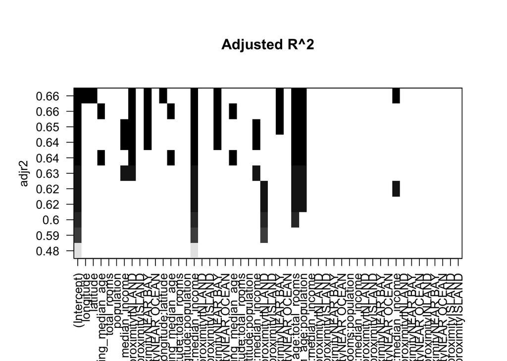

```r
# The output of this is long and not very pretty, there is better output below.
#regsubsets2.out

summary2.out <- summary(regsubsets2.out)
dont_print_df = as.data.frame(summary2.out$outmat)
## Adjusted R2
plot(regsubsets2.out, scale = "adjr2", main = "Adjusted R^2")
```

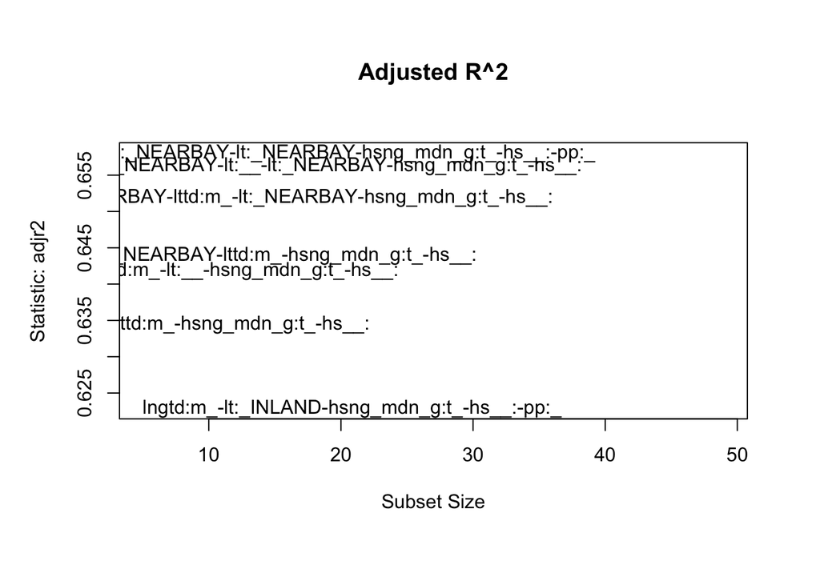

```r
#layout(matrix(1:2, ncol = 2))
## Adjusted R2
res.legend = subsets(regsubsets2.out, statistic="adjr2", legend = FALSE, min.size = 5, main = "Adjusted R^2")
## Mallow Cp - A small value of Cp means that the model is relatively precise
#res.legend = subsets(regsubsets2.out, statistic="cp", legend = FALSE, min.size = 5, main = "Mallow Cp")
abline(a = 1, b = 1, lty = 2)
```

```r
res.legend
```

```
##                                               Abbreviation
## longitude                                               ln
## latitude                                                lt
## housing_median_age                                    hs__
## total_rooms                                            tt_
## population                                              pp
## median_income                                          md_
## ocean_proximityINLAND                                 o_IN
## ocean_proximityISLAND                                 o_IS
## ocean_proximityNEAR BAY                                 oB
## ocean_proximityNEAR OCEAN                               oO
## longitude:latitude                                 lngtd:l
## longitude:housing_median_age                         ln:__
## longitude:total_rooms                             lngtd:t_
## longitude:population                               lngtd:p
## longitude:median_income                           lngtd:m_
## longitude:ocean_proximityINLAND                 ln:_INLAND
## longitude:ocean_proximityISLAND                 ln:_ISLAND
## longitude:ocean_proximityNEAR BAY              ln:_NEARBAY
## longitude:ocean_proximityNEAR OCEAN          ln:_NEAROCEAN
## latitude:housing_median_age                          lt:__
## latitude:total_rooms                               lttd:t_
## latitude:population                                    lt:
## latitude:median_income                             lttd:m_
## latitude:ocean_proximityINLAND                  lt:_INLAND
## latitude:ocean_proximityISLAND                  lt:_ISLAND
## latitude:ocean_proximityNEAR BAY               lt:_NEARBAY
## latitude:ocean_proximityNEAR OCEAN           lt:_NEAROCEAN
## housing_median_age:total_rooms               hsng_mdn_g:t_
## housing_median_age:population                        hs__:
## housing_median_age:median_income             hsng_mdn_g:m_
## housing_median_age:ocean_proximityINLAND           h__:_IN
## housing_median_age:ocean_proximityISLAND           h__:_IS
## housing_median_age:ocean_proximityNEAR BAY              hB
## housing_median_age:ocean_proximityNEAR OCEAN            hO
## total_rooms:population                                tt_:
## total_rooms:median_income                            tt_:_
## total_rooms:ocean_proximityINLAND                   t_:_IN
## total_rooms:ocean_proximityISLAND                   t_:_IS
## total_rooms:ocean_proximityNEAR BAY                     tB
## total_rooms:ocean_proximityNEAR OCEAN                   tO
## population:median_income                              pp:_
## population:ocean_proximityINLAND                     p:_IN
## population:ocean_proximityNEAR BAY                      pB
## population:ocean_proximityNEAR OCEAN                    pO
## median_income:ocean_proximityINLAND                 m_:_IN
## median_income:ocean_proximityNEAR BAY                   mB
## median_income:ocean_proximityNEAR OCEAN                 mO
## population:ocean_proximityISLAND                     p:_IS
## median_income:ocean_proximityISLAND                 m_:_IS
```

```r
which.max(summary2.out$adjr2)
```

[output not shown]

```r
summary2.out$which[which.max(summary2.out$adjr2),]
```

```
##                                  (Intercept)
##                                         TRUE
##                                    longitude
##                                         TRUE
##                                     latitude
##                                         TRUE
##                           housing_median_age
##                                        FALSE
##                                  total_rooms
##                                        FALSE
##                                   population
##                                        FALSE
##                                median_income
##                                        FALSE
##                        ocean_proximityINLAND
##                                         TRUE
##                        ocean_proximityISLAND
##                                        FALSE
##                      ocean_proximityNEAR BAY
##                                         TRUE
##                    ocean_proximityNEAR OCEAN
##                                        FALSE
##                           longitude:latitude
##                                         TRUE
##                 longitude:housing_median_age
##                                        FALSE
##                        longitude:total_rooms
##                                        FALSE
##                         longitude:population
##                                        FALSE
##                      longitude:median_income
##                                         TRUE
##              longitude:ocean_proximityINLAND
##                                        FALSE
##              longitude:ocean_proximityISLAND
##                                        FALSE
##            longitude:ocean_proximityNEAR BAY
##                                         TRUE
##          longitude:ocean_proximityNEAR OCEAN
##                                        FALSE
```

[output cut: 45 more lines]

```
##                                        FALSE
##             population:ocean_proximityISLAND
##                                        FALSE
##           population:ocean_proximityNEAR BAY
##                                        FALSE
##         population:ocean_proximityNEAR OCEAN
##                                        FALSE
##          median_income:ocean_proximityINLAND
##                                        FALSE
##          median_income:ocean_proximityISLAND
##                                        FALSE
##        median_income:ocean_proximityNEAR BAY
##                                        FALSE
##      median_income:ocean_proximityNEAR OCEAN
##                                        FALSE
```

```r
best_leaps_model = lm(median_house_value ~ longitude + latitude + I(ocean_proximity == "INLAND") + I(ocean_proximity == "NEAR BAY") + longitude:latitude + longitude:median_income + longitude:I(ocean_proximity == "NEAR BAY") + housing_median_age:total_rooms + housing_median_age:population + population:median_income, data = housing_data)
summary(best_leaps_model)
```

```
##
## Call:
## lm(formula = median_house_value ~ longitude + latitude + I(ocean_proximity ==
##     "INLAND") + I(ocean_proximity == "NEAR BAY") + longitude:latitude +
##     longitude:median_income + longitude:I(ocean_proximity ==
##     "NEAR BAY") + housing_median_age:total_rooms + housing_median_age:population +
##     population:median_income, data = housing_data)
##
## Residuals:
##     Min      1Q  Median      3Q     Max
## -483828  -43242  -10768   29502  458824
##
## Coefficients:
##                                                  Estimate Std. Error
## (Intercept)                                    -1.466e+07  7.526e+05
## longitude                                      -1.294e+05  6.226e+03
## latitude                                        3.422e+05  2.194e+04
## I(ocean_proximity == "INLAND")TRUE             -6.084e+04  1.810e+03
## I(ocean_proximity == "NEAR BAY")TRUE           -2.857e+07  1.205e+06
## longitude:latitude                              3.029e+03  1.801e+02
## longitude:median_income                        -2.793e+02  2.748e+00
## longitude:I(ocean_proximity == "NEAR BAY")TRUE -2.336e+05  9.856e+03
## housing_median_age:total_rooms                  8.946e-01  2.027e-02
## housing_median_age:population                  -1.052e+00  3.509e-02
## median_income:population                       -1.497e+00  1.124e-01
##                                                t value Pr(>|t|)
## (Intercept)                                     -19.48   <2e-16 ***
## longitude                                       -20.78   <2e-16 ***
## latitude                                         15.60   <2e-16 ***
## I(ocean_proximity == "INLAND")TRUE              -33.61   <2e-16 ***
## I(ocean_proximity == "NEAR BAY")TRUE            -23.71   <2e-16 ***
## longitude:latitude                               16.82   <2e-16 ***
## longitude:median_income                        -101.61   <2e-16 ***
## longitude:I(ocean_proximity == "NEAR BAY")TRUE  -23.71   <2e-16 ***
## housing_median_age:total_rooms                   44.13   <2e-16 ***
## housing_median_age:population                   -29.98   <2e-16 ***
## median_income:population                        -13.32   <2e-16 ***
## ---
## Signif. codes:  0 '***' 0.001 '**' 0.01 '*' 0.05 '.' 0.1 ' ' 1
##
## Residual standard error: 68310 on 20629 degrees of freedom
## Multiple R-squared:  0.6498, Adjusted R-squared:  0.6496
## F-statistic:  3827 on 10 and 20629 DF,  p-value: < 2.2e-16
```

This is an interesting set of variables and makes a lot of sense. Housing prices are likely tied to the big cites (San Francisco, Los Angeles, etc.). A couple of ways to denote these are latitude, longitude and whether the location is near a Bay. Median Income may also be a proxy for the larger cities versus the more rural areas.

```r
tied_best_leaps_model = lm(median_house_value ~ housing_median_age + I(ocean_proximity == "INLAND") + I(ocean_proximity == "NEAR BAY") + longitude:housing_median_age + longitude:median_income + longitude:I(ocean_proximity == "NEAR BAY") + housing_median_age:total_rooms + housing_median_age:population, data = housing_data)
summary(tied_best_leaps_model)
```

```
##
## Call:
## lm(formula = median_house_value ~ housing_median_age + I(ocean_proximity ==
##     "INLAND") + I(ocean_proximity == "NEAR BAY") + longitude:housing_median_age +
##     longitude:median_income + longitude:I(ocean_proximity ==
##     "NEAR BAY") + housing_median_age:total_rooms + housing_median_age:population,
##     data = housing_data)
##
## Residuals:
##     Min      1Q  Median      3Q     Max
## -490802  -44018  -11363   29026  474607
##
## Coefficients:
##                                                  Estimate Std. Error
## (Intercept)                                     7.510e+04  2.046e+03
## housing_median_age                              9.726e+02  1.156e+03
## I(ocean_proximity == "INLAND")TRUE             -8.406e+04  1.184e+03
## I(ocean_proximity == "NEAR BAY")TRUE           -2.868e+07  1.240e+06
## housing_median_age:longitude                    3.128e+00  9.644e+00
## longitude:median_income                        -2.798e+02  2.478e+00
## I(ocean_proximity == "NEAR BAY")TRUE:longitude -2.345e+05  1.014e+04
## housing_median_age:total_rooms                  7.740e-01  2.073e-02
## housing_median_age:population                  -1.058e+00  3.475e-02
##                                                 t value Pr(>|t|)
## (Intercept)                                      36.708   <2e-16 ***
## housing_median_age                                0.842    0.400
## I(ocean_proximity == "INLAND")TRUE              -71.021   <2e-16 ***
## I(ocean_proximity == "NEAR BAY")TRUE            -23.129   <2e-16 ***
## housing_median_age:longitude                      0.324    0.746
## longitude:median_income                        -112.919   <2e-16 ***
## I(ocean_proximity == "NEAR BAY")TRUE:longitude  -23.124   <2e-16 ***
## housing_median_age:total_rooms                   37.334   <2e-16 ***
## housing_median_age:population                   -30.462   <2e-16 ***
## ---
## Signif. codes:  0 '***' 0.001 '**' 0.01 '*' 0.05 '.' 0.1 ' ' 1
##
## Residual standard error: 70040 on 20631 degrees of freedom
## Multiple R-squared:  0.6318, Adjusted R-squared:  0.6316
## F-statistic:  4424 on 8 and 20631 DF,  p-value: < 2.2e-16
```

```r
second_best_leaps_model = lm(median_house_value ~ median_income + I(ocean_proximity == "INLAND") + I(ocean_proximity == "NEAR BAY") + longitude:median_income + latitude:median_income + longitude:I(ocean_proximity == "NEAR BAY") + housing_median_age:total_rooms + housing_median_age:population, data = housing_data)
summary(second_best_leaps_model)
```

```
##
## Call:
## lm(formula = median_house_value ~ median_income + I(ocean_proximity ==
##     "INLAND") + I(ocean_proximity == "NEAR BAY") + longitude:median_income +
##     latitude:median_income + longitude:I(ocean_proximity == "NEAR BAY") +
##     housing_median_age:total_rooms + housing_median_age:population,
##     data = housing_data)
##
## Residuals:
##     Min      1Q  Median      3Q     Max
## -472751  -41648  -12111   28327  463583
##
## Coefficients:
##                                                  Estimate Std. Error
## (Intercept)                                     8.977e+04  1.609e+03
## median_income                                  -6.176e+05  2.103e+04
## I(ocean_proximity == "INLAND")TRUE             -5.410e+04  1.612e+03
## I(ocean_proximity == "NEAR BAY")TRUE           -2.834e+07  1.207e+06
## median_income:longitude                        -7.697e+03  2.484e+02
## median_income:latitude                         -7.648e+03  2.581e+02
## I(ocean_proximity == "NEAR BAY")TRUE:longitude -2.318e+05  9.870e+03
## housing_median_age:total_rooms                  7.982e-01  2.016e-02
## housing_median_age:population                  -1.046e+00  3.386e-02
##                                                t value Pr(>|t|)
## (Intercept)                                      55.79   <2e-16 ***
## median_income                                   -29.37   <2e-16 ***
## I(ocean_proximity == "INLAND")TRUE              -33.55   <2e-16 ***
## I(ocean_proximity == "NEAR BAY")TRUE            -23.49   <2e-16 ***
## median_income:longitude                         -30.98   <2e-16 ***
## median_income:latitude                          -29.64   <2e-16 ***
## I(ocean_proximity == "NEAR BAY")TRUE:longitude  -23.49   <2e-16 ***
## housing_median_age:total_rooms                   39.60   <2e-16 ***
## housing_median_age:population                   -30.89   <2e-16 ***
## ---
## Signif. codes:  0 '***' 0.001 '**' 0.01 '*' 0.05 '.' 0.1 ' ' 1
##
## Residual standard error: 68860 on 20631 degrees of freedom
## Multiple R-squared:  0.6441, Adjusted R-squared:  0.6439
## F-statistic:  4666 on 8 and 20631 DF,  p-value: < 2.2e-16
```